# Homework 8

#### Rice 11.35

An experiment was done to measure the effects of ozone, a component of smog. A group of 22 seventy-day-old rats were kept in an environment containing ozone for 7 days, and their weight gains were recorded. Another group of 23 rats of a similar age were kept in an ozone-free environment for a similar time, and their weight gains were recorded. The data (in grams) are given below. Analyze the data to determine the effect of ozone. Write a summary of your conclusions. [This problem is from Doksum and Sievers (1976) who provide an interesting analysis.]

```r
control = c(41.0,25.9,13.1,-16.9,15.4,22.4,29.4,26.0,38.4,21.9,27.3,17.4,27.4,17.7,21.4,26.6,24.9,18.3,28.5,21.8,19.2,26.0,22.7)
ozone = c(10.1,7.3,-9.9,17.9,6.6,39.9,-14.7,-9.0,6.1,14.3,6.8,-12.9,12.1,-15.9,44.1,20.4,15.5,28.2,14.0,15.7,54.6,-9.0)
```

Find the mean and the standard error.

```r
control_bar = mean(control)
ozone_bar = mean(ozone)
sprintf("mean of control: %s, mean of ozone : %s", control_bar, ozone_bar)
```

```
[1] "mean of control: 22.4260869565217, mean of ozone : 11.0090909090909"
```

```r
control_var = var(control)
ozone_var = var(ozone)
sprintf("var of control: %s, var of ozone : %s", control_bar, ozone_var)
```

```
[1] "var of control: 22.4260869565217, var of ozone : 361.65038961039"
```

Find the pooled sample variance.

```r
n = length(control)
m = length(ozone)
pooled_var = ((n - 1) * control_var + (m - 1) * ozone_var) / (n + m - 2)
sprintf("pooled variance: %s", pooled_var)
```

```
[1] "pooled variance: 236.039593712657"
```

Calculate the test statistic.

```r
test_statistic = (control_bar - ozone_bar) / sqrt(pooled_var * (1 / n + 1 / m))
sprintf("test statistic: %s", test_statistic)
```

```
[1] "test statistic: 2.49188745102729"
```

```r
p = 2 * (1 - pnorm(test_statistic))
sprintf("p-value: %s", p)
```

```
[1] "p-value: 0.0127066294677709"
```

Reject the null hypothesis that there is no effect.

#### Rice 11.36

Lin, Sutton, and Qurashi (1979) compared microbiological and hydroxylamine methods for the analysis of ampicillin dosages. In one series of experiments, pairs of tablets were analyzed by the two methods. The data in the following table give the percentages of claimed amount of ampicillin found by the two methods in several pairs of tablets. What are X − Y and s X −Y ? If the pairing had been erro- neously ignored and it had been assumed that the two samples were independent, what would have been the estimate of the standard deviation of X − Y ? Ana- lyze the data to determine if there is a systematic difference between the two methods.

```r
micro = c(97.2,105.8,99.5,100.0,93.8,79.2,72.0,72.0,69.5,20.5,95.2,90.8,96.2,96.2,91.0)
hydro = c(97.2,97.8,96.2,101.8,88.0,74.0,75.0,67.5,65.8,21.2,94.8,95.8,98.0,99.0,100.2)
```

Calculate mean, sample variances and the test statistic, if the data is pair-wise.

```r
diff = micro - hydro
diff_bar = mean(diff)
diff_var = var(diff)
test_statistic = diff_bar / sqrt(diff_var / length(diff))
test_statistic
```

```
[1] 0.367998
```

Calculate p-value.

```r
p = 2 * (1 - pnorm(test_statistic))
p
```

```
[1] 0.7128748
```

Do the same calculations if it is independent.

```r
n = length(micro)
pooled_var = (var(micro) + var(hydro)) / 2
test_statistic = (mean(micro) - mean(hydro)) / sqrt(2 * pooled_var / n)
p = 2 * (1 - pnorm(test_statistic))
p
```

```
[1] 0.9550455
```

You would not reject it in either case, so there is no significant difference.

#### Rice 11.37

Stanley and Walton (1961) ran a controlled clinical trial to investigate the effect of the drug stelazine on chronic schizophrenics. The trials were conducted on chronic schizophrenics in two closed wards. In each of the wards, the patients were divided into two groups matched for age, length of time in the hospital, and score on a behavior rating sheet. One member of each pair was given stelazine, and the other a placebo. Only the hospital pharmacist knew which member of each pair received the actual drug. The following table gives the behavioral rating scores for the patients at the beginning of the trial and after 3 mo. High scores are good.

1. For each of the wards, test whether stelazine is associated with improvement in the patients’ scores.

Data for patients with Stelazine and placebo before and after.

```r
sb = c(2.3,2.0,1.9,3.1,2.2,2.3,2.8,1.9,1.1)
sa = c(3.1,2.1,2.45,3.7,2.54,3.72,4.54,1.61,1.63)
pb = c(2.4,2.2,2.1,2.9,2.2,2.4,2.7,1.9,1.3)
pa = c(2.0,2.6,2.0,2.0,2.4,3.18,3.0,2.54,1.72)
s_diff = sa - sb
p_diff = pa - pb
```

```r
n = length(s_diff)
pooled_var = (var(s_diff) + var(p_diff)) / 2
test_statistic = (mean(s_diff) - mean(p_diff)) / sqrt(2 * pooled_var / n)
p = 2 * (1 - pt(test_statistic, df = 2 * n - 2))
p
```

```
[1] 0.08923099
```

```r
t.test(s_diff, p_diff, alternative = 'less')
```

```
    Welch Two Sample t-test

data:  s_diff and p_diff
t = 1.8093, df = 15.612, p-value = 0.9552
alternative hypothesis: true difference in means is less than 0
95 percent confidence interval:
      -Inf 0.9722867
sample estimates:
mean of x mean of y
0.6433333 0.1488889
```

#### Rice 11.39

An experiment was done to test a method for reducing faults on telephone lines (Welch 1987). Fourteen matched pairs of areas were used. The following table shows the fault rates for the control areas and for the test areas:

```r
test = c(676,206,230,256,280,433,337,466,497,512,794,428,452,512)
control = c(88,570,605,617,653,2913,924,286,1098,982,2346,321,615,519)
```

1. Plot the differences versus the control rate and summarize what you see.

```r
plot(test)
points(control, pch = 5)
```

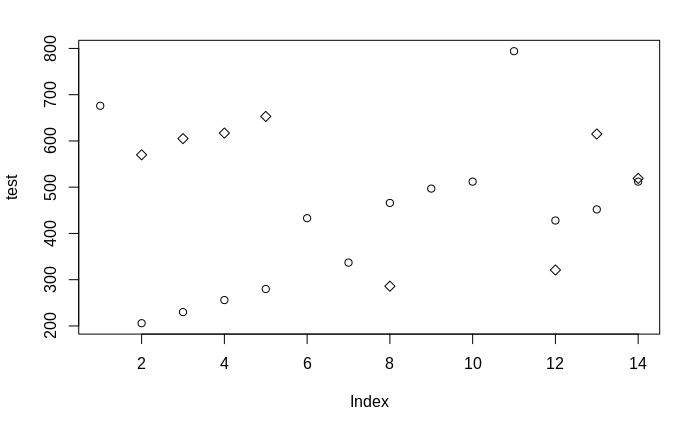

```r
legend(1, 95, legend = c('test', 'control'), col = c('red', 'blue'))
```

Circle is test, diamond is control.

2. Calculate the mean difference, its standard deviation, and a confidence interval.

```r
diff = test - control
mean = mean(diff)
var = var(diff)
sprintf("mean: %s, sample var: %s", mean, var)
```

```
[1] "mean: -461.285714285714, sample var: 574274.835164835"
```

```r
alpha = 0.95
t = qt((1 + alpha) / 2, df = length(diff))
me = t * sqrt(var / length(diff))
lower = mean - me
upper = mean + me
sprintf("%s confidence interval for the change is (%s, %s)", alpha, lower, upper)
```

```
[1] "0.95 confidence interval for the change is (-895.675875942667, -26.8955526287613)"
```

We reject that there is not a significant difference between the new method and the control group.